[OHI British Columbia](http://www.ohibc.org/) | [OHI Science](http://ohi-science.org) | [Citation policy](https://github.com/OHI-Science/ohiprep/releases)

# OHIBC: Sea Level Rise Pressure layers prep

Compiled on Thu Mar 17 16:41:57 2016 by ohara

# 1 Summary

There are two parts to creating this layer:

1. Data prep to get raw data into the correct format:
   - Read sea level rise data as raster
   - Clip rasters to extents of OHIBC region, and reproject into BC Albers projection.
2. Creating the pressure layers for OHIBC:
   - All negative values, indicating decreases in sea level, were set to zero
   - Data was resampled from the native cell resolution (0.25 degrees) to ~ 1km
   - The reference point was set as the 99.99th quantile of the data distribution to rescale all values from 0 to 1
   - All NA cells were filled in through nearest neighbor interpolation

This process is completed entirely within this script.

# 2 Data

Reference: The altimeter products were produced and distributed by Aviso (http://www.aviso.altimetry.fr/), as part of the Ssalto ground processing segment. AVISO

- Downloaded: January 12, 2015
- Description: Annual rate of sea level rise in mm
- Native data resolution: 0.25 degree grid cells
- Time range: January 1993 - June 2014
- Format: NetCDF

# 3 Methods

## 3.1 Data Prep

### 3.1.1 Read raw data

What is really the format here? velocity? only single year? use as a trend, or get multi-year data from same source?

Range of SLR velocity for global dataset: -36.3780382002635 - 35.5727103654705 mm yr<sup>-1</sup>.

### 3.1.2 Convert raw global data to OHIBC region data

The raw data, in WGS84 coordinate ref system, is rasterized, clipped down to a bounding box around the OHIBC region, and reprojected into BC Albers projection. This data is then resampled to 1 km resolution using nearest neighbor method.

The resulting raster layers include mean SLR velocity for each coarse cell (approx .25 degree, from original resolution)

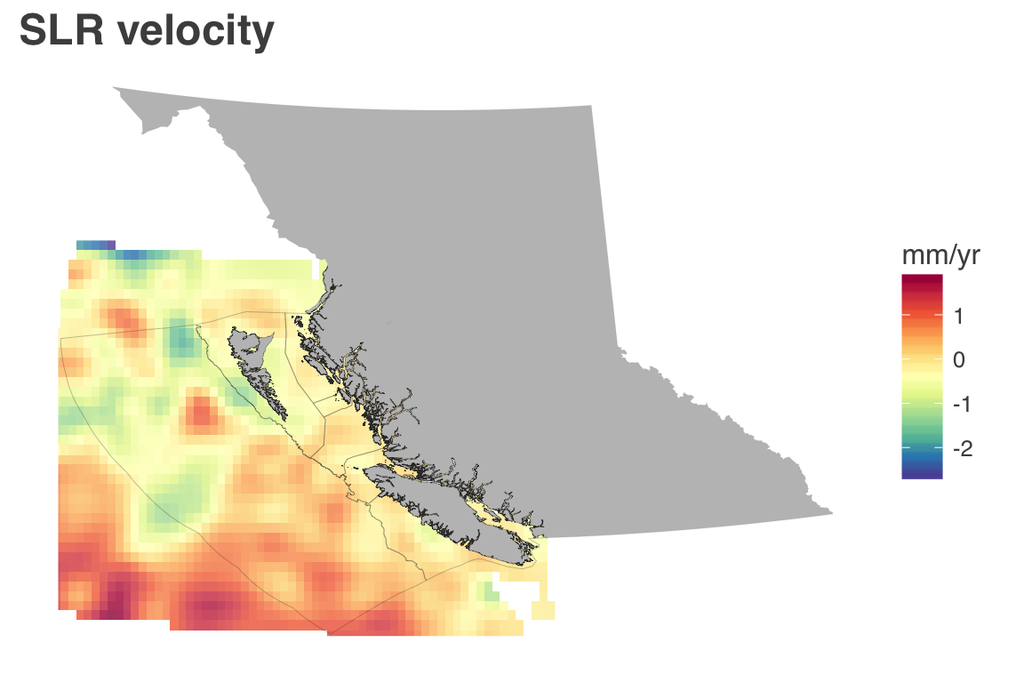

## 3.2 Rescale values as pressures

Values below zero (lowering sea level) are set to zero.

Then rescaled from zero (no positive sea level rise) to 1 (at 99.99%ile of velocity).

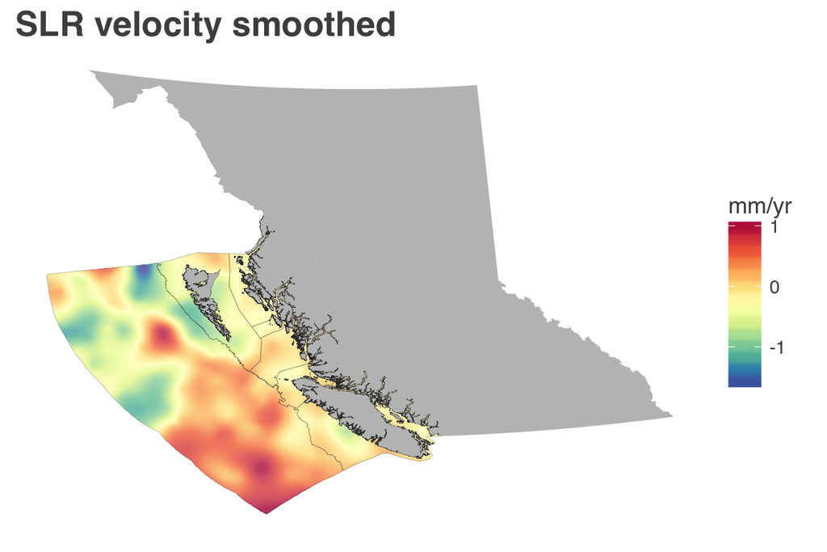

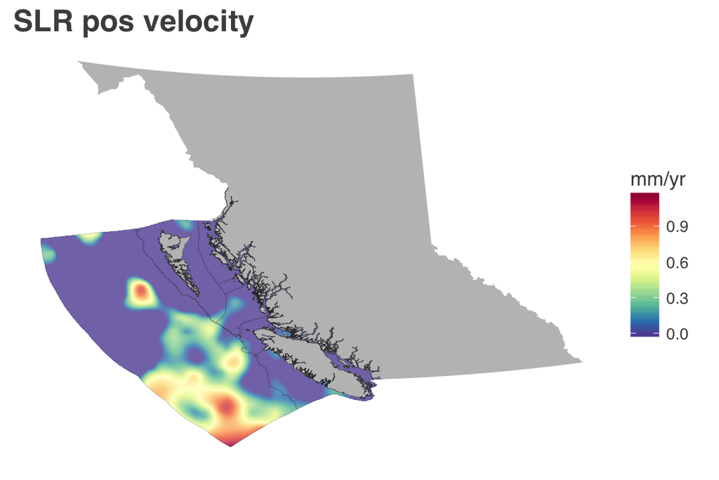

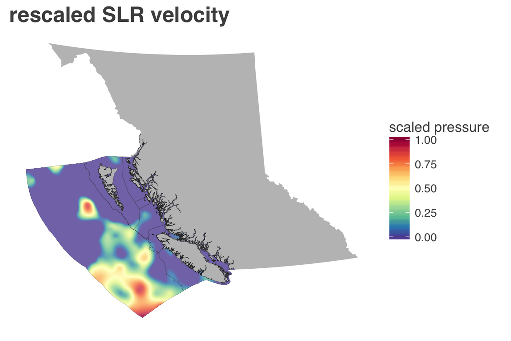

## 3.3 Calculate mean pressure by region by year

Using 1000 m region ID raster to run zonal statistics on the pressures layers, calculate the regional average pressures for the study period, and save as a .csv.

| rgn_id | pressure | rgn_name |
| --- | --- | --- |
| 1 | 0.0000000 | North Coast |
| 2 | 0.0099263 | Haida Gwaii |
| 3 | 0.0225611 | Central Coast |
| 4 | 0.0204391 | North Vancouver Island |
| 5 | 0.0227116 | West Vancouver Island |
| 6 | 0.0000000 | Strait of Georgia |
| 7 | 0.1845756 | Pacific Offshore |
| 8 | 0.0000000 | Aristazabal Island |

# 4 Provenance

- *Run ID: 2; run tag: “standard run”*
- *Run elapsed time: 168.905 seconds; run memory usage: NA MB*
- *System info: System: Darwin, Release: 15.3.0. Machine: x86_64. User: ohara.*
- *Session info*
  - *R version: R version 3.2.2 (2015-08-14), Platform: x86_64-apple-darwin13.4.0, Running under: OS X 10.11.3 (El Capitan).*
  - *Attached base packages: stats, graphics, grDevices, utils, datasets, methods, base*
  - *Other attached packages: maptools_0.8-39, RColorBrewer_1.1-2, ncdf4_1.15, ggplot2_2.1.0, readr_0.2.2, stringr_1.0.0, tidyr_0.4.1, dplyr_0.4.3, raster_2.5-2, rgdal_1.0-4, sp_1.2-2*

Provenance summary for this run:

| run_id | run_tag | run_date | file_loc | type | commit_url | commit_author | commit_date | uncommitted_changes |
| --- | --- | --- | --- | --- | --- | --- | --- | --- |
| 2 | standard run | Thu Mar 17 16:44:49 2016 | ~/github/ohibc/prep/pressures/v2016/pressures_lyr_fxns.R | sourced_script | https://github.com/OHI-Science/ohibc/commit/5f6534a816eedf6fbe016bfeb156a5d4295fff85 | Casey O’Hara ohara@nceas.ucsb.edu | Tue Mar 15 11:09:01 2016 -0700 | FALSE |
| 2 | standard run | Thu Mar 17 16:44:49 2016 | ~/github/ohibc/src/R/rast_tools.R | sourced_script | https://github.com/OHI-Science/ohibc/commit/6fac3638d2a10f9836c6f059dfbadc3a5011b1bf | Casey O’Hara ohara@nceas.ucsb.edu | Wed Mar 16 15:34:30 2016 -0700 | FALSE |
| 2 | standard run | Thu Mar 17 16:44:49 2016 | ~/github/ohiprep/globalprep/Pressures_SeaLevelRise/v2015/raw/MSL_Map_MERGED_Global_IB_RWT_NoGIA_Adjust.nc | input | no version control info found | NA | NA | TRUE |
| 2 | standard run | Thu Mar 17 16:44:49 2016 | /Users/ohara/github/ohibc/prep/regions/ohibc_rgn.shp | input | https://github.com/OHI-Science/ohibc/commit/b4848d164d7ab5393da401425b57d0a540866c1f | Casey O’Hara ohara@nceas.ucsb.edu | Wed Oct 28 15:07:36 2015 -0700 | FALSE |
| 2 | standard run | Thu Mar 17 16:44:49 2016 | /Users/ohara/github/ohibc/prep/regions/ohibc_rgn_wgs84.shp | input | https://github.com/OHI-Science/ohibc/commit/b014927db4445d63bc01ddf683252c301cd59d0f | Casey O’Hara ohara@nceas.ucsb.edu | Wed Oct 28 11:55:33 2015 -0700 | FALSE |
| 2 | standard run | Thu Mar 17 16:44:49 2016 | ~/github/ohibc/prep/regions/ohibc_rgn_raster_1000m.tif | input | https://github.com/OHI-Science/ohibc/commit/c4744464da326817b3f3c0f5634f5bfbd2f59e12 | Casey O’Hara ohara@nceas.ucsb.edu | Tue Mar 15 15:05:57 2016 -0700 | FALSE |
| 2 | standard run | Thu Mar 17 16:44:49 2016 | ~/github/ohibc/prep/pressures/v2016/int/slr/rast_slr_raw.tif | input | https://github.com/OHI-Science/ohibc/commit/ec2b37a1f6364de9bc979f0a908bae55ec076222 | Casey O’Hara ohara@nceas.ucsb.edu | Thu Mar 17 16:13:56 2016 -0700 | FALSE |
| 2 | standard run | Thu Mar 17 16:44:49 2016 | ~/github/ohibc/prep/pressures/v2016/output/slr/slr_rescaled.tif.shp | output | no version control info found | NA | NA | TRUE |
| 2 | standard run | Thu Mar 17 16:44:49 2016 | ~/github/ohibc/prep/pressures/v2016/output/slr/slr_rgn_pressures.csv | output | New commit: https://github.com/OHI-Science/ohibc/commit/5f4c7a57d1b01ff1b1ac68836ac6e2740e445b2d | Casey O’Hara ohara@nceas.ucsb.edu | Thu Mar 17 16:44:48 2016 -0700 | FALSE |
| 2 | standard run | Thu Mar 17 16:44:49 2016 | ~/github/ohibc/prep/pressures/v2016/pressures_slr_prep.Rmd | script | https://github.com/OHI-Science/ohibc/commit/ec2b37a1f6364de9bc979f0a908bae55ec076222 | Casey O’Hara ohara@nceas.ucsb.edu | Thu Mar 17 16:13:56 2016 -0700 | TRUE |